# Challenge 5: Visualizaing Time and Space

Author

Kuan-Cheng Lee

Published

November 1, 2024

**Make sure you change the author’s name and add the data in the above YAML header.**

## Setup

If you have not installed the following packages, please install them before loading them.

```r
# for data wrangling
library(dplyr)
library(tidyr)
library(lubridate)
library(readr)

#for plotting over time
library(ggplot2)


# for plotting over space
library(sp)
library(sf)
library(maps)
```

## Challenge Overview

In this challenge, we will practice the visualization skills learned in the class with two datasets to capture the temporal and spatial patterns.

There will be coding components and writing components. Please read the instructions for each part and complete the associated tasks and questions.

## Datasets

- Part 1. The UFO Sightings Data (50%)
- Part 2. The Hospital Location Data (50%)

Download the files from Canvas, save them in the proper place in your DACSSS 601 folder, and then read the datasets using the correct R commands.

## Part 1. The UFO Sightings Data (5 pts)

This data contains over 80,000 reports of UFO sightings over the last century in six major countries (and other places). You can learn more about this data by checking: https://www.kaggle.com/datasets/NUFORC/ufo-sightings.

1. **Read and Describe the Data (0.5 pts)**

   What are the dimensions of the data? What do the columns mean? What is the unit of observation? **There are 12 columns and 88875 rows in the data. The first column present the year, month, and date. The second comlumn present the cities that UFO be recorded. The third column present the city belong to the state. The fourth column present the countries which the UFO showed up. The fifth column present the shape of the UFO. The sixth column present the duration time for the UFO.**

   ```r
   # type your code here.
   ufo_data <- read.csv("complete_UFO.csv")
   numberofCol <- ncol(ufo_data)
   numberofRow <- nrow(ufo_data)

   numberofCol
   ```

   ```
   [1] 12
   ```

   ```r
   numberofRow
   ```

   ```
   [1] 88875
   ```

   ```r
   head(ufo_data)
   ```

   |  | datetime | city | state | country | shape | duration..seconds. | duration..hours.min. | comments | date.posted | latitude | longitude | X |
   | --- | --- | --- | --- | --- | --- | --- | --- | --- | --- | --- | --- | --- |
   | 1 | 11/11/1906 | wien (austria) |  |  | other | 10800 | 3 h | The oldest professional photo of a UFO object is from Wien observatory&#44 in 1906&#33 | 12/23/2002 | 48.208174 | 16.373819 | NA |
   | 2 | 1/2/1910 | kirksville (near) | mo | us | disk | 120 | minutes | Historical sighting (1903 - 1913) Northern Missouri | 9/15/2005 | 40.1947222 | -92.583056 | NA |
   | 3 | 5/28/1910 | solon | me | us | unknown | 0 | don&#39t know | entry in my great-grandmother&#39s diary&#44date 28 may 1910&#44refers to watching the comet zig-zaging in the sky&#44 followed by a zig-zag diagra | 12/5/2001 | 44.9494444 | -69.858889 | NA |
   | 4 | 6/1/1910 | wills point | tx | us | cigar | 120 | 2 minutes | Cigar shaped object moving from West to East | 4/16/2005 | 32.7091667 | -96.008056 | NA |
   | 5 | 9/15/1914 | meeting lake (canada) | ab |  | unknown | 0 |  | Night flying &quot;airplane&quot; with search lights observed on several occasions near Meeting Lake&#44 Alberta in late 1914. | 2/1/2007 | 55.170828 | -118.837956 | NA |
   | 6 | 4/5/1916 | france (above; from aircraft) |  |  | cigar | 60 | about 1 min. | ((NUFORC Note: Possible hoax. PD)) Saw 3 cigar shaped crafts. | 3/9/2004 | 46.227638 | 2.213749 | NA |

2. Please plot a temporal/time-series graph to present the following patterns. **You may need to subset or mutate the data for graphing.**

   (1) the total number of UFO sighting reports over the years. **(1.5 pts)**

   ```r
   # type your code here.
   # Extract the year from the date column and calculate total sightings per year
   # Check the structure of the dataset
   str(ufo_data)
   ```

   ```
   'data.frame':   88875 obs. of  12 variables:
    $ datetime            : chr  "11/11/1906" "1/2/1910" "5/28/1910" "6/1/1910" ...
    $ city                : chr  "wien (austria)" "kirksville (near)" "solon" "wills point" ...
    $ state               : chr  "" "mo" "me" "tx" ...
    $ country             : chr  "" "us" "us" "us" ...
    $ shape               : chr  "other" "disk" "unknown" "cigar" ...
    $ duration..seconds.  : chr  "10800" "120" "0" "120" ...
    $ duration..hours.min.: chr  "3 h" "minutes" "don&#39t know" "2 minutes" ...
    $ comments            : chr  "The oldest professional photo of a UFO object is from Wien observatory&#44 in 1906&#33" "Historical sighting (1903 - 1913) Northern Missouri" "entry in my great-grandmother&#39s diary&#44date 28 may 1910&#44refers to watching the comet zig-zaging in the "| __truncated_…
    $ date.posted         : chr  "12/23/2002" "9/15/2005" "12/5/2001" "4/16/2005" ...
    $ latitude            : chr  "48.208174" "40.1947222" "44.9494444" "32.7091667" ...
    $ longitude           : num  16.4 -92.6 -69.9 -96 -118.8 ...
    $ X                   : int  NA NA NA NA NA NA NA NA NA 0 ...
   ```

   ```r
   # Preview the first few rows of the dataset
   head(ufo_data)
   ```

   |  | datetime | city | state | country | shape | duration..seconds. | duration..hours.min. | comments | date.posted | latitude | longitude | X |
   | --- | --- | --- | --- | --- | --- | --- | --- | --- | --- | --- | --- | --- |
   | 1 | 11/11/1906 | wien (austria) |  |  | other | 10800 | 3 h | The oldest professional photo of a UFO object is from Wien observatory&#44 in 1906&#33 | 12/23/2002 | 48.208174 | 16.373819 | NA |
   | 2 | 1/2/1910 | kirksville (near) | mo | us | disk | 120 | minutes | Historical sighting (1903 - 1913) Northern Missouri | 9/15/2005 | 40.1947222 | -92.583056 | NA |
   | 3 | 5/28/1910 | solon | me | us | unknown | 0 | don&#39t know | entry in my great-grandmother&#39s diary&#44date 28 may 1910&#44refers to watching the comet zig-zaging in the sky&#44 followed by a zig-zag diagra | 12/5/2001 | 44.9494444 | -69.858889 | NA |
   | 4 | 6/1/1910 | wills point | tx | us | cigar | 120 | 2 minutes | Cigar shaped object moving from West to East | 4/16/2005 | 32.7091667 | -96.008056 | NA |
   | 5 | 9/15/1914 | meeting lake (canada) | ab |  | unknown | 0 |  | Night flying &quot;airplane&quot; with search lights observed on several occasions near Meeting Lake&#44 Alberta in late 1914. | 2/1/2007 | 55.170828 | -118.837956 | NA |
   | 6 | 4/5/1916 | france (above; from aircraft) |  |  | cigar | 60 | about 1 min. | ((NUFORC Note: Possible hoax. PD)) Saw 3 cigar shaped crafts. | 3/9/2004 | 46.227638 | 2.213749 | NA |

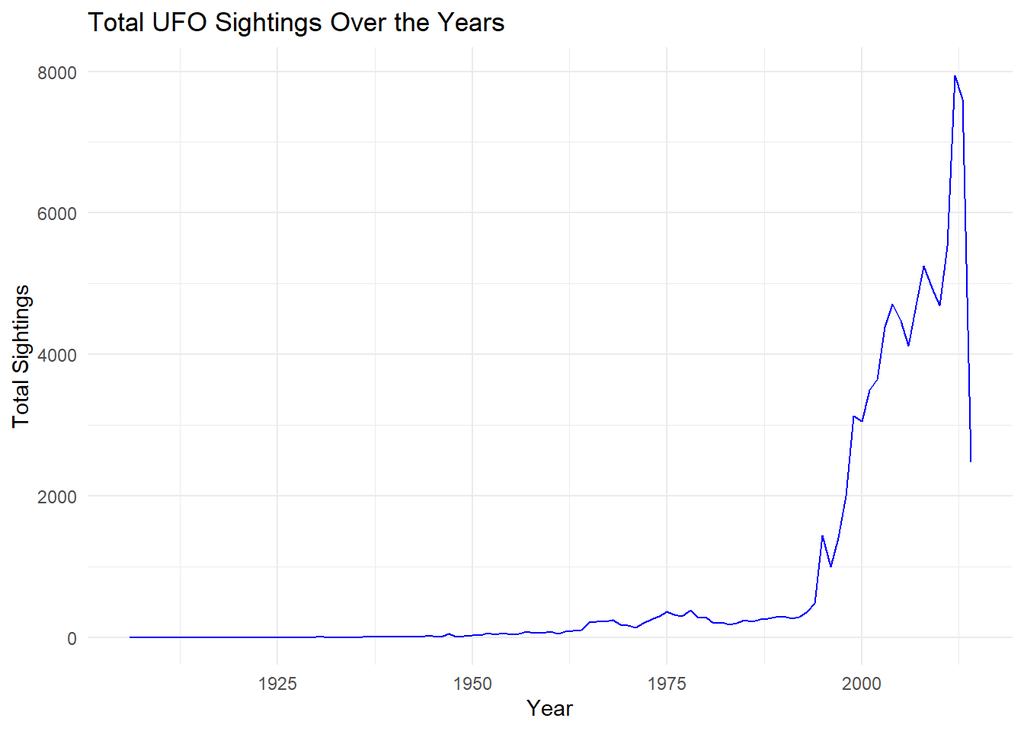

   ```r
   # Parse the date column with a specific format
   ufo_data <- ufo_data %>%
     mutate(datetime = as.Date(datetime, format = "%m/%d/%Y"))



      # Extract year and calculate total sightings per year
   ufo_yearly <- ufo_data %>%
     mutate(year = year(datetime)) %>%
     filter(!is.na(year)) %>%
     group_by(year) %>%
     summarize(total_sightings = n())

   # Plot total UFO sightings over the years
   ggplot(ufo_yearly, aes(x = year, y = total_sightings)) +
     geom_line(color = "blue") +
     labs(
       title = "Total UFO Sightings Over the Years",
       x = "Year",
       y = "Total Sightings"
     ) +
     theme_minimal()
   ```

   (2) the total number of UFO sighting reports by months between 2 010-01-01 and 2014-01-01. **(1.5 pts)**

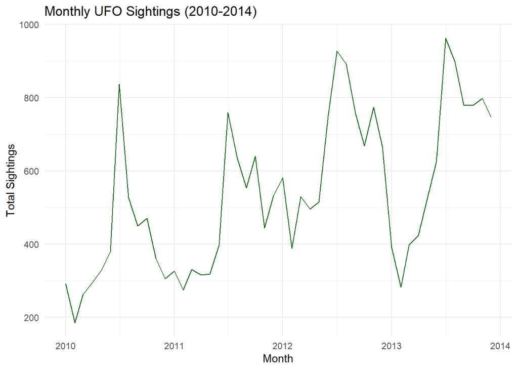

   ```r
   #type of your code/command here.
   # Filter data for the date range and extract year and month
   ufo_monthly <- ufo_data %>%
     mutate(date = as.Date(`datetime`, format = "%Y-%m-%d")) %>%  # Replace with actual column name
     filter(date >= as.Date("2010-01-01") & date < as.Date("2014-01-01")) %>%
     mutate(month = floor_date(date, "month")) %>%
     group_by(month) %>%
     summarize(total_sightings = n())

   # Plot total UFO sightings by month (2010-2014)
   ggplot(ufo_monthly, aes(x = month, y = total_sightings)) +
     geom_line(color = "darkgreen") +
     labs(
       title = "Monthly UFO Sightings (2010-2014)",
       x = "Month",
       y = "Total Sightings"
     ) +
     theme_minimal()
   ```

3. Please write a paragraph describing the patterns you find on the two graphs above. **(1.5 pts)** **In the first graph, showing the total UFO sightings over the years, a clear upward trend emerges. Sightings appear to have increased gradually from earlier decades, with a more pronounced rise in reports starting around the 1990s and peaking in recent years. This trend could reflect an increasing public interest in UFOs or more accessible reporting channels over time.**

**The second graph, displaying monthly UFO sightings from January 2010 to January 2014, reveals a seasonal pattern in the data. Sightings tend to peak during the summer months (June to August) each year, with fewer reports in the winter months. This seasonality might indicate that warmer weather and longer daylight hours encourage more outdoor activity, leading to increased chances of observing and reporting UFOs. The consistency of these summer peaks across multiple years suggests a recurring, likely environmental influence on sighting frequency.**

4. **(Optional)** Use `gganimte` and `gifsky` packages to plot gifs of the above time-series plots. You can refer to codes and commands from the Week 9 code. **(0 pts)**

   ```r
   # type your code here.
   ```

5. **(Optional)** Suppose we are interested in describing the country variations in types and numbers of UFO sighting reports. How can we use bar plots to visualize the difference across countries (using the `country` column, you can recode the empty cells with `"others"`)? Is this an effective visualization? Why or why not? **Note that you may need to do data transformation or mutation in order to make the graph.** **(0 pts)**

   ```r
   # type your code here.
   ```

## Part 2. The Hospital Location Data (5 pts)

This data contains the locations of hospitals in the United States. You can learn more about this data by checking: https://www.kaggle.com/datasets/andrewmvd/us-hospital-locations

1. **Read and Describe the Data (0.5 pts)**

   What are the dimensions of the data? What do the columns mean? What is the unit of observation?

   ```r
   # type your code here.
   # Read the hospital data
   hospital_data <- read_csv("us_hospital_locations.csv")
   # Display dimensions and first few rows
   dim(hospital_data)
   ```

   ```
   [1] 7596   15
   ```

   ```r
   head(hospital_data)
   ```

   | ID | NAME | ADDRESS | CITY | STATE | ZIP | TYPE | STATUS | POPULATION | COUNTY | COUNTRY | LATITUDE | LONGITUDE | OWNER | BEDS |
   | --- | --- | --- | --- | --- | --- | --- | --- | --- | --- | --- | --- | --- | --- | --- |
   | 5793230 | CENTRAL VALLEY GENERAL HOSPITAL | 1025 NORTH DOUTY STREET | HANFORD | CA | 93230 | GENERAL ACUTE CARE | CLOSED | 49 | KINGS | USA | 36.33616 | -119.6457 | PROPRIETARY | 49 |
   | 53391362 | LOS ROBLES HOSPITAL & MEDICAL CENTER - EAST CAMPUS | 150 VIA MERIDA | WESTLAKE VILAGE | CA | 91362 | GENERAL ACUTE CARE | OPEN | 62 | VENTURA | USA | 34.15494 | -118.8157 | PROPRIETARY | 62 |
   | 11190023 | EAST LOS ANGELES DOCTORS HOSPITAL | 4060 WHITTIER BOULEVARD | LOS ANGELES | CA | 90023 | GENERAL ACUTE CARE | OPEN | 127 | LOS ANGELES | USA | 34.02365 | -118.1842 | PROPRIETARY | 127 |
   | 17090028 | SOUTHERN CALIFORNIA HOSPITAL AT HOLLYWOOD | 6245 DE LONGPRE AVENUE | HOLLYWOOD | CA | 90028 | GENERAL ACUTE CARE | OPEN | 100 | LOS ANGELES | USA | 34.09639 | -118.3252 | PROPRIETARY | 100 |
   | 23691706 | KINDRED HOSPITAL BALDWIN PARK | 14148 FRANCISQUITO AVENUE | BALDWIN PARK | CA | 91706 | GENERAL ACUTE CARE | OPEN | 95 | LOS ANGELES | USA | 34.06304 | -117.9674 | PROPRIETARY | 95 |
   | 25190712 | LAKEWOOD REGIONAL MEDICAL CENTER | 3700 EAST SOUTH STREET | LAKEWOOD | CA | 90712 | GENERAL ACUTE CARE | OPEN | 172 | LOS ANGELES | USA | 33.85971 | -118.1484 | PROPRIETARY | 172 |

2. Download the `cb_2018_us_state_500k.shp` data from https://www2.census.gov/geo/tiger/GENZ2018/shp/cb_2018_us_state_500k.zip). Put the whole `cb_2018_us_state_500k` folder in your data folder. Plot a USA map with states boundaries using `geom_sf()`. **(1.5 pts)**

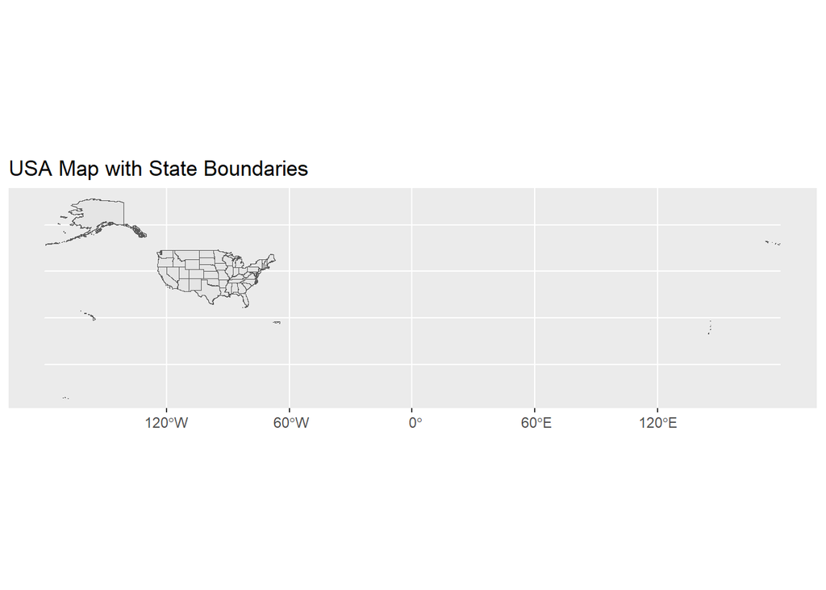

   ```r
   # type your code here.
   # Read the shapefile for USA state boundaries
   usa_states <- st_read("cb_2018_us_state_500k/cb_2018_us_state_500k.shp")
   # Plot the USA map with state boundaries
   ggplot(data = usa_states) +
     geom_sf() +
     ggtitle("USA Map with State Boundaries")
   ```

3. Plot the hospital locations using the *LONGITUDE* and *LATITUDE* with `geom_point()` on the USA map generated above. Mark OPEN and CLOSED hospitals using different colors. **(1.5 pts)**

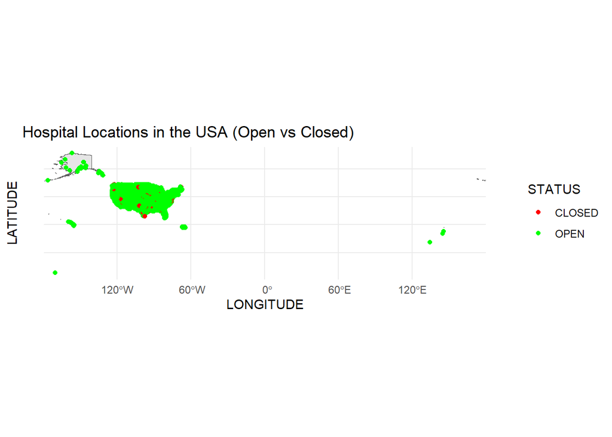

   ```r
   # type your code here.
   # Plot the USA map with hospitals
   ggplot(data = usa_states) +
     geom_sf() +
     geom_point(data = hospital_data, aes(x = LONGITUDE, y = LATITUDE, color = STATUS)) +
     ggtitle("Hospital Locations in the USA (Open vs Closed)") +
     theme_minimal() +
     scale_color_manual(values = c("OPEN" = "green", "CLOSED" = "red"))
   ```

4. Please write a paragraph describing the pattern of the hospital locations you find on the map above. **(1.5 pts)**